# droughtR: An R package for estimating non-stationary meteorological droughts

[figure not shown]

### Summary

`droughtR` is a free open-source software provided as an R package that enables to compute a model-based non-stationary meteorological drought index (NSPI) using the GAMLSS framework. It includes multiple features such as:

1. The computation of a model-based meteorological drought index that incorporates the trend of accumulated precipitation at different time scales
2. Visualization support of the stationary and non-stationary meteorological drought indices
3. Comparison between model-based drought indices using statistical measures

### Statement of need

The standardized precipitation index (SPI) (McKee et al. 1993), is a very well known drought index that defines and monitors meteorological drought events. The computation of SPI involves fitting a probability distribution function on accumulated rainfall series at different time scales (e.g., 3 month accumulation), with Gamma distribution being the most popular as it is simple and can very well describe the accumulated precipitation (Guenang and Kamga 2014; H. Wang et al. 2019). Positive SPI values indicate wet conditions with greater than the median precipitation, while negative SPI values indicate dry conditions with lower than the median precipitation.

In a changing climate where precipitation exhibits non-stationarity, traditional SPI calculation involves fitting the accumulated precipitation to a time-invariant probability density function, resulting to a trending SPI series that reflects the trend of accumulated precipitation (Shiau 2020). To avoid this limitation, different versions of a non-stationary standardized precipitation index (NSPI) have been proposed using a time-varying probability density function that models precipitation under climate change. Y. Wang et al. (2015), developed a time-dependent SPI by fitting generalized additive models in location, scale, and shape (GAMLSS) (Stasinopoulos, Rigby, et al. 2007) to monitor regional droughts during the summer period in the Luanhe River basin in China. Also, Mammas and Lekkas (2021) computed, both, SPI and NSPI in 36.500 basins in Sweden and showed the limitations of SPI during out-of-sample validation in time series forecasting. Across studies, results suggest that under non-stationarity in precipitation, the use of the traditional SPI does not lead to accurate drought classification.

Some dedicated tools for monitoring SPI already exist: `spi` is an R package that computes SPI at different time scales (Neves 2011). `SPEI` package is an additional R package that computes SPI and the standardized precipitation evapotranspiration index (SPEI) using various distributions, including, ‘log-Logistic’, ‘Gamma’ and ‘PearsonIII’ (Beguerı́a and Vicente-Serrano 2017). In Python, `climate-indices` is a library that implements various climate index algorithms which provide a geographical and temporal picture of the severity of precipitation and temperature anomalies useful for climate monitoring and research (Adams 2017).

Although the aforementioned packages provide great flexibility to compute SPI under stationarity, they are unable to characterize meteorological droughts efficiently in non-stationary environments. `droughtR` solves this limitation as it enables users with limited coding skills to compute NSPI at different time scales and make direct comparison with the stationary version of SPI. It computes NSPI using a very well known R package called, `GAMLSS`, that estimates the time-varying *location* and *scale* distribution parameters of various distributions, such as Gamma, Zero Inflated Gamma, Normal and Weibull, as a function of the increasing trend of accumulated precipitation. `droughtR` is available on https://github.com/mammask/droughtR and can be downloaded through the R library `devtools`.

`droughtR` is designed to be used by hydrologists, environmentalists, researchers and data scientists that work with environmental data. It offers a simplistic coding interface that generates inputs for drought monitoring and drought forecasting applications.

### Features

#### Computation of Stationary and Non-Stationary SPI

The main use of `droughtR` is for characterizing and monitoring meteorological drought events under stationary and non-stationary scenarios. In the following example, `droughtR` is used to generate a synthetic rainfall series and compute NSPI:

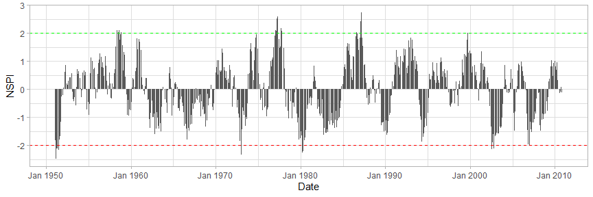

```r
# Load droughtR library
library(droughtR)

# Generate synthetic monthly rainfall data using the Gamma distribution
rain = dummyrainfall(startYear = 1950, endYear = 2010)

# Compute the non-stationary standardized precipitation index (NSPI) for scale 12 using GAMLSS
spi = computenspi(x = rain, stationaryspi = FALSE, spiScale = 12, dist = 'gamma')

# Plot NSPI
plot(spi)
```

Equivalently, the stationary version of SPI is computed as follows:

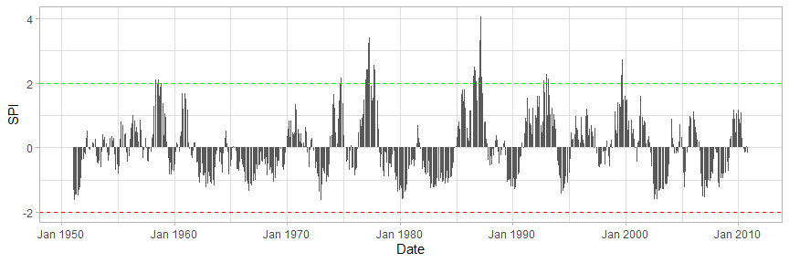

```r
# calculate NSPI
spi = computenspi(monthlyRainfall = rain, stationaryspi = TRUE, spiScale = 12)

# plot results
plot(spi)
```

#### Visualize drought events over time

The classification of drought events can be visualized over time:

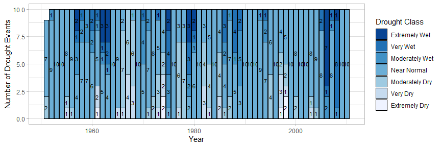

```r
# Build a graph with drought events over time
indexClass = computeclass(mIndex)

plot(indexClass)
```

### References

Adams, James. 2017. “Climate_indices, an Open Source Python Library Providing Reference Implementations of Commonly Used Climate Indices.” https://github.com/monocongo/climate_indices.

Beguerı́a, Santiago, and Sergio M Vicente-Serrano. 2017. “Package ’Spei’.” *Calculation of the Standardised Precipitation-Evapotranspiration Index, CRAN [Package]*.

Guenang, Guy Merlin, and F Mkankam Kamga. 2014. “Computation of the Standardized Precipitation Index (SPI) and Its Use to Assess Drought Occurrences in Cameroon over Recent Decades.” *Journal of Applied Meteorology and Climatology* 53 (10): 2310–24.

Mammas, Konstantinos, and Demetris F Lekkas. 2021. “Characterization of Bias During Meteorological Drought Calculation in Time Series Out-of-Sample Validation.” *Water* 13 (18): 2531.

McKee, Thomas B, Nolan J Doesken, John Kleist, et al. 1993. “The relationship of drought frequency and duration to time scales.” In *Proceedings of the 8th Conference on Applied Climatology*, 17:179–83. Boston.

Neves, Josemir. 2011. “Package ’Spi’.” *Compute the SPI Index Using R*.

Shiau, Jenq-Tzong. 2020. “Effects of gamma-distribution variations on SPI-based stationary and nonstationary drought analyses.” *Water Resources Management* 34: 2081–95.

Stasinopoulos, D Mikis, Robert A Rigby, et al. 2007. “Generalized additive models for location scale and shape (GAMLSS) in R.” *Journal of Statistical Software* 23 (7): 1–46.

Wang, Huaijun, Yaning Chen, Yingping Pan, Zhongsheng Chen, and Zhiguo Ren. 2019. “Assessment of candidate distributions for SPI/SPEI and sensitivity of drought to climatic variables in China.” *International Journal of Climatology* 39 (11): 4392–412.

Wang, Yixuan, Jianzhu Li, Ping Feng, and Rong Hu. 2015. “A time-dependent drought index for non-stationary precipitation series.” *Water Resources Management* 29 (15): 5631–47.